# H11 Stage 2: implementation and V0 comparison

Nature Health analysis audit — author approval gate

Published

August 1, 2026

**ImportantStage 2 author decision required**

The approved H11-METHOD-001 through H11-METHOD-007 analysis is complete. The primary near-eye result, complementary chest result, gap-timing-unaware sensitivity, diagnostics, V0 comparison, and the authorised 50-resample effect-size pilot are reported below. No production bootstrap, leave-one-site- out refit, or reader-facing H11 notebook has been run. The final section lists the decisions needed to proceed.

## 1 Question and implementation status

The signed preregistered hypothesis is:

> H11: Diurnal exposure patterns differ by sex.

The measured predictor is **biological sex**, recorded as Female or Male. Gender is a distinct recorded construct; it is neither substituted for sex nor entered in an H11 model. The estimand is the complete conditional Female-minus- Male difference in `log10(30-minute arithmetic-mean melEDI + 0.1 lx)` across the 48 observed half-hour clock-bin midpoints, equally averaged over the fixed included site support. Near eye is primary; chest is complementary.

The final model uses the H02 clock-time, participant/day hierarchy, site deviation, AR(1), boundary, and diagnostic decisions without reselecting them. The observation is the analysis unit and participant is the independent inference cluster. Results are associational and conditional on the included sites.

## 2 Exact fitted samples

The accepted main samples reconcile exactly to H02: 141 participants, 816 participant-days, and 37,756 half-hour observations at 9 sites near eye; and 154 participants, 902 participant-days, and 41,842 observations at 8 sites at the chest. The sex join lost no fitted row.

Exact fitted-model samples

Female and Male columns are participant counts; nominal hours equal half the observation count.

| Analysis | Participants | Female | Male | Participant-days | 30-minute observations | Nominal hours | Sites |
| --- | --- | --- | --- | --- | --- | --- | --- |
| Near eye — primary dataset | 141 | 79 | 62 | 816 | 37,756 | 18,878.0 | 9 |
| Chest — primary dataset | 154 | 86 | 68 | 902 | 41,842 | 20,921.0 | 8 |
| Near eye — gap-timing-unaware dataset | 141 | 79 | 62 | 809 | 37,603 | 18,801.5 | 9 |
| Chest — gap-timing-unaware dataset | 154 | 86 | 68 | 894 | 41,664 | 20,832.0 | 8 |

## 3 Exact model and accepted inference

### 3.1 Wilkinson formulas supplied to the fits

The following evaluated objects are the exact formulas supplied to `mgcv`. `M_pattern` was used for all four final fREML fits. `M0` was fitted only for the two main-placement descriptive effect-size branches after their global tests opened those branches.

**Exact final H11 formula**

```r
cat(h11_formula_text(formulas$proposed_mpattern), "\n")
```

```
response ~ sex + s(time_hour, bs = "cc", k = 12) + s(time_hour, by = sex_smooth, bs = "cc", k = 12) + s(time_hour, site, bs = "sz", k = 12) + s(time_hour, participant, bs = "fs", k = 10) + s(participant_day, bs = "re")
```

**Exact conditional effect-size baseline formula**

```r
cat(h11_formula_text(formulas$proposed_m0), "\n")
```

```
response ~ s(time_hour, bs = "cc", k = 12) + s(time_hour, site, bs = "sz", k = 12) + s(time_hour, participant, bs = "fs", k = 10) + s(participant_day, bs = "re")
```

Both use Gaussian identity-link `bam()` fits with `method = "fREML"`, `discrete = TRUE`, cyclic knots at 0 and 24 hours, and one run-specific rho estimated from a rho-zero preliminary full model. Male is the treatment- contrast reference. `sex_smooth` is the same biological-sex field ordered Male then Female, yielding one cyclic Female-minus-Male deviation.

Durable core fits

The obsolete ML/discrete = FALSE comparison branch produced no accepted checkpoint and is not part of inference.

| Analysis | Stage | Method | Discrete | Elapsed (seconds) | Checkpoint reused | Converged |
| --- | --- | --- | --- | --- | --- | --- |
| Near eye — primary dataset | Preliminary full model, rho = 0 | fREML | TRUE | 69.3 | TRUE | TRUE |
| Near eye — primary dataset | Final full model, accepted rho | fREML | TRUE | 55.6 | TRUE | TRUE |
| Chest — primary dataset | Preliminary full model, rho = 0 | fREML | TRUE | 84.4 | TRUE | TRUE |
| Chest — primary dataset | Final full model, accepted rho | fREML | TRUE | 90.7 | TRUE | TRUE |
| Near eye — gap-timing-unaware dataset | Preliminary full model, rho = 0 | fREML | TRUE | 75.4 | TRUE | TRUE |
| Near eye — gap-timing-unaware dataset | Final full model, accepted rho | fREML | TRUE | 89.3 | TRUE | TRUE |
| Chest — gap-timing-unaware dataset | Preliminary full model, rho = 0 | fREML | TRUE | 70.0 | TRUE | TRUE |
| Chest — gap-timing-unaware dataset | Final full model, accepted rho | fREML | TRUE | 130.5 | TRUE | TRUE |

### 3.2 Participant-cluster-robust curve test

The global null is that the complete Female-minus-Male curve is zero at all 48 clock-bin midpoints. From each final `M_pattern` fit, the accepted method:

1. applies the run-specific AR(1) whitening transformation to the design and residuals, resetting at every accepted H02 `AR.start` boundary;
2. sums scores across all rows and days within participant;
3. forms a participant-cluster CR1 sandwich covariance and adds the `mgcv` smoothing-bias component `Vp - Ve`; and
4. uses the `mgcv` fractional-rank Wald statistic with finite-cluster F reference and denominator degrees of freedom `participants - ceiling(reference rank)`.

This is H11-METHOD-001 through H11-METHOD-007. It replaces, outcome-aware, the unfinished ML/AIC branch. There is no delta-AIC support rule.

Multiplicity is fixed before display: one global test per placement or sensitivity run (`planned n = 1`), and BH adjustment across the two planned level/shape decomposition tests within each run (`planned n = 2`). Raw and adjusted p-values below are labelled and formatted independently. Bold raw p-values meet the raw 0.050 rule; bold adjusted p-values meet the separately labelled adjusted 0.050 rule.

## 4 Primary and complementary results

The complete near-eye Female-minus-Male curve test is supported ($F = 20.95$, fractional numerator df = 9.69, denominator df = 131, raw p = **0.028**, BH-adjusted p = **0.028**). The complementary chest curve test is also supported ($F = 4.88$, fractional numerator df = 1.00, denominator df = 152, raw p = **0.029**, BH-adjusted p = **0.029**).

Global complete-curve tests

Each global family has planned n = 1. Near eye is primary; chest is complementary.

| Analysis | F statistic | Numerator df | Denominator df | Raw p | BH-adjusted p | Decision |
| --- | --- | --- | --- | --- | --- | --- |
| Near eye — primary dataset | 20.95 | 9.69 | 131 | **0.028** | **0.028** | Supported |
| Chest — primary dataset | 4.88 | 1.00 | 152 | **0.029** | **0.029** | Supported |
| Near eye — gap-timing-unaware dataset | 20.50 | 9.61 | 131 | **0.026** | **0.026** | Supported |
| Chest — gap-timing-unaware dataset | 4.42 | 1.00 | 152 | **0.037** | **0.037** | Supported |

The predeclared decomposition does **not** isolate a supported level or shape component after BH adjustment. For near eye, the shape raw p is **0.043** but its BH-adjusted p is 0.075; for chest, the level raw p is **0.029** but its BH-adjusted p is 0.057. These raw values are styled under the separately labelled raw 0.050 rule but are not substituted for the adjusted decomposition decision.

Level/shape decomposition

BH adjustment is applied within each two-test placement family. Raw and adjusted values are styled independently.

| Placement | Component | F statistic | Numerator df | Denominator df | Raw p | BH-adjusted p | Decision |
| --- | --- | --- | --- | --- | --- | --- | --- |
| Near eye | Constant level | 3.213 | 1.000 | 140 | 0.075 | 0.075 | Not supported after BH |
| Near eye | Cyclic shape | 17.896 | 8.692 | 132 | **0.043** | 0.075 | Not supported after BH |
| Chest | Constant level | 4.877 | 1.000 | 153 | **0.029** | 0.057 | Not supported after BH |
| Chest | Cyclic shape | 0.000 | 0.003 | 153 | 0.986 | 0.986 | Not supported after BH |

### 4.1 Primary near-eye curves and pointwise intervals

All curve intervals are participant-cluster-robust **pointwise 95% confidence intervals** at the 48 displayed bin midpoints. They are not simultaneous over the day. Contiguous pointwise exclusions are descriptive and cannot establish a familywise-supported significant period.

The smallest primary Female-to-Male shifted-value ratio occurs at 08:45 and is 0.47 (pointwise 95% CI 0.28 to 0.78). The largest is 1.27 at 22:15 (pointwise 95% CI 0.68 to 2.36). These local summaries do not replace the global test.

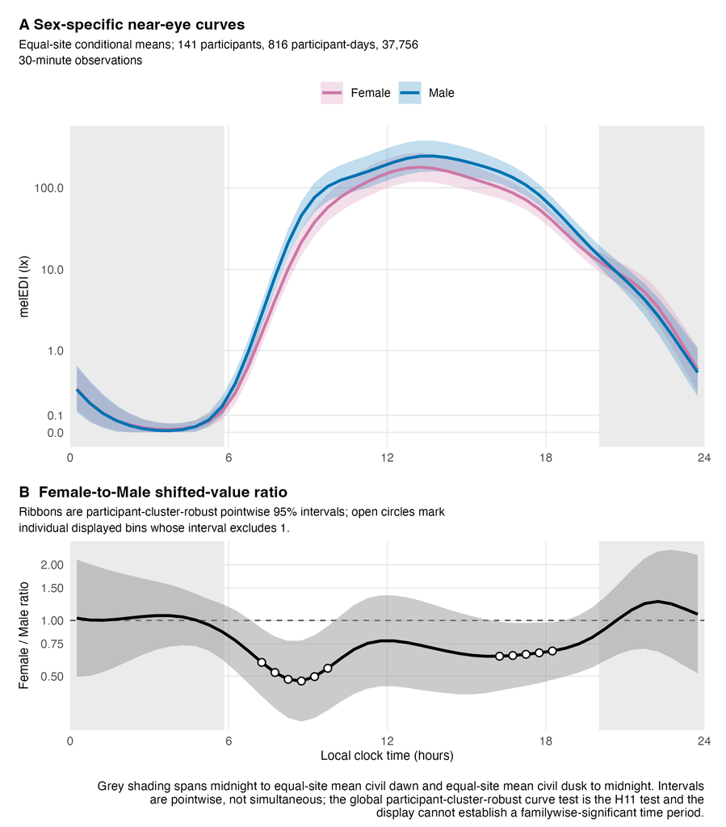

Primary near-eye biological-sex curves and Female-to-Male shifted-value ratios. Ribbons are participant-cluster-robust pointwise 95% confidence intervals. Open circles identify individual displayed bins whose pointwise interval excludes one. The intervals are not simultaneous, and the display does not establish a familywise-significant period; the global participant-cluster-robust curve test is the H11 test.

Descriptive near-eye pointwise segments

No simultaneous coverage and no significant-period claim.

| Direction | Displayed interval | 30-minute bins | Ratio range | Pointwise envelope |
| --- | --- | --- | --- | --- |
| Female lower (pointwise) | 07:00:00–10:00:00 | 6 | 0.47–0.59 | 0.28–0.93 |
| Female lower (pointwise) | 16:00:00–18:30:00 | 5 | 0.64–0.68 | 0.42–0.98 |

### 4.2 Complementary chest curves and pointwise intervals

The chest Female-to-Male ratio is nearly time-invariant at 0.79 (pointwise 95% CI 0.65 to 0.98). All 48 displayed chest pointwise intervals exclude one; the figure omits 48 redundant open circles to keep the curve legible. This remains a pointwise statement, not simultaneous evidence for an all-day period. The formal evidence is the complementary global curve test, while the BH-adjusted level/shape decomposition remains unsupported.

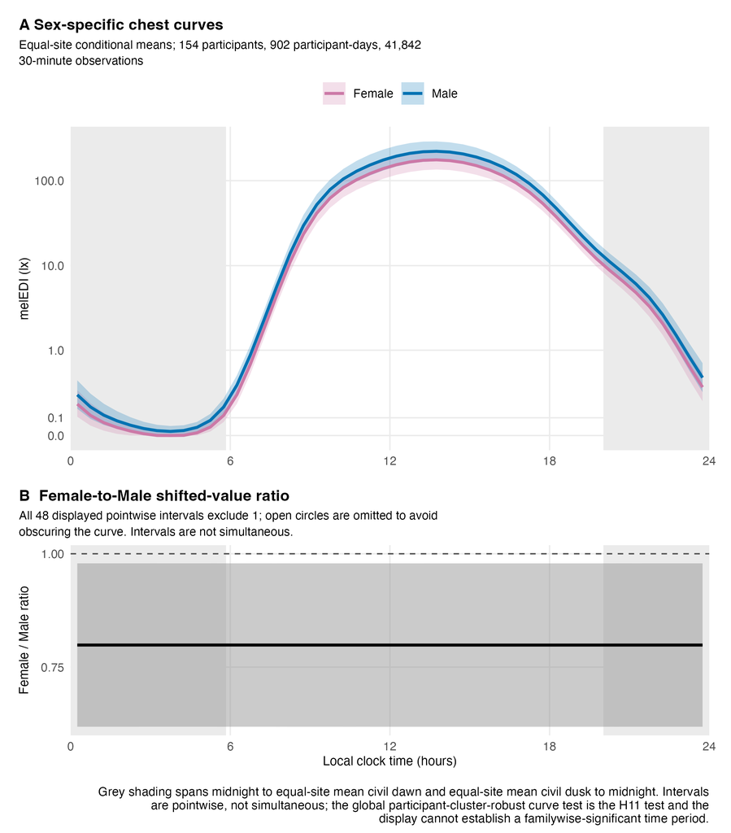

Complementary chest biological-sex curves and Female-to-Male shifted-value ratios. All 48 displayed participant-cluster-robust pointwise 95% confidence intervals exclude one, so redundant open circles are omitted. The intervals are not simultaneous and do not establish an all-day familywise-significant period; the global curve test is the formal complementary test.

Descriptive parametric level component

Participant-cluster-robust pointwise intervals; decomposition decisions use the BH-adjusted tests above.

| Placement | Female / Male shifted ratio | Pointwise 95% CI | Scope |
| --- | --- | --- | --- |
| Near eye | 0.808 | 0.639–1.022 | Parametric level conditional on the cyclic sex deviation |
| Chest | 0.793 | 0.645–0.976 | Parametric level conditional on the cyclic sex deviation |

## 5 Conditional biological-sex effect sizes

The author-approved gate opens within a main placement when its one-test global robust raw p-value is below 0.050. It opened for near eye (raw p = **0.028**) and chest (raw p = **0.029**), so an H02-like `M0` baseline was fitted under fREML/discrete and exactly 50 hierarchical resamples were run as the authorised pilot. No effect-size baseline was fitted for the sensitivity datasets.

The prediction-based estimates are very small. They are descriptive in-sample relevance measures on the transformed response scale, not causal effects, cross-validated prediction, or a unique partition of observed variance. A small negative chest increment can occur because the baseline and full models were smoothed separately under fREML; it indicates a negligible descriptive increment rather than negative variance explained.

Conditional H02-like biological-sex effect-size pilot

PILOT ONLY: 50 hierarchical resamples; intervals are not approved for inference or manuscript reporting.

| Placement | Estimator | Estimate | Pilot 95% interval | Resamples |
| --- | --- | --- | --- | --- |
| Near eye | Allocated in-sample R² increment | 0.000021 | -0.000319 to 0.000499 | 50 |
| Near eye | Share of full-model R² | 0.000028 | -0.000412 to 0.000651 | 50 |
| Near eye | Partial R² | 0.000096 | -0.001424 to 0.002273 | 50 |
| Chest | Allocated in-sample R² increment | −0.000034 | -0.000097 to 0.000039 | 50 |
| Chest | Share of full-model R² | −0.000046 | -0.000134 to 0.000054 | 50 |
| Chest | Partial R² | −0.000129 | -0.000335 to 0.000141 | 50 |

Equal-clock fitted-curve variation across biological sex

The two sex curves are equally weighted over the 48 displayed clock bins.

| Placement | Estimate | Robust delta-method 95% CI | Unit | Role |
| --- | --- | --- | --- | --- |
| Near eye | 0.0113 | 0.0000 to 0.0306 | squared log10(melEDI + 0.1 lx) prediction units | Conditional descriptive effect size; not variance explained |
| Chest | 0.0051 | 0.0000 to 0.0141 | squared log10(melEDI + 0.1 lx) prediction units | Conditional descriptive effect size; not variance explained |

The 50-resample pilot took 0.061 seconds near eye and 0.066 seconds at the chest. Linear projection from this fixed-prediction resampling gives 2.44 seconds (upper planning estimate 3.66 seconds) and 2.64 seconds (upper 3.96 seconds), respectively, for 2,000 resamples. These timings do not include model refits because the approved estimator resamples stored fixed predictions. A production run still requires explicit approval.

## 6 Gap-timing-unaware sensitivity

The **gap-timing-unaware dataset** still passed the general 50%-per-hour and 80%-per-day coverage rules. “Gap-timing-unaware” means that the timing of the remaining missing observations is not used for metric-specific adjustment. For contrast in this first explanation only, the primary dataset could be interpreted as a **time-sensitive primary metric dataset**. From here onward it is called simply the primary dataset, while this sensitivity remains the gap-timing-unaware dataset.

The global conclusion is stable. Near eye gives raw p = **0.026** and BH-adjusted p = **0.026** on the gap-timing-unaware dataset, versus raw p = **0.028** and BH-adjusted p = **0.028** on the primary dataset. Chest gives raw p = **0.037** and BH-adjusted p = **0.037**, versus raw p = **0.029** and BH-adjusted p = **0.029**, respectively. After holding the accepted model and robust inference fixed, the primary preparation adds 7 near-eye participant- days and 153 observations, and 8 chest participant-days and 178 observations.

Data-preparation comparison with inference held fixed

Bold raw p-values meet the explicitly labelled raw 0.050 rule.

| Placement | Primary participants | Primary participant-days | Gap-timing-unaware participant-days | Added days | Added observations | Primary raw p | Gap-timing-unaware raw p | Stability |
| --- | --- | --- | --- | --- | --- | --- | --- | --- |
| Near eye | 141 | 816 | 809 | 7 | 153 | **0.028** | **0.026** | Stable |
| Chest | 154 | 902 | 894 | 8 | 178 | **0.029** | **0.037** | Stable |

**Near eye**

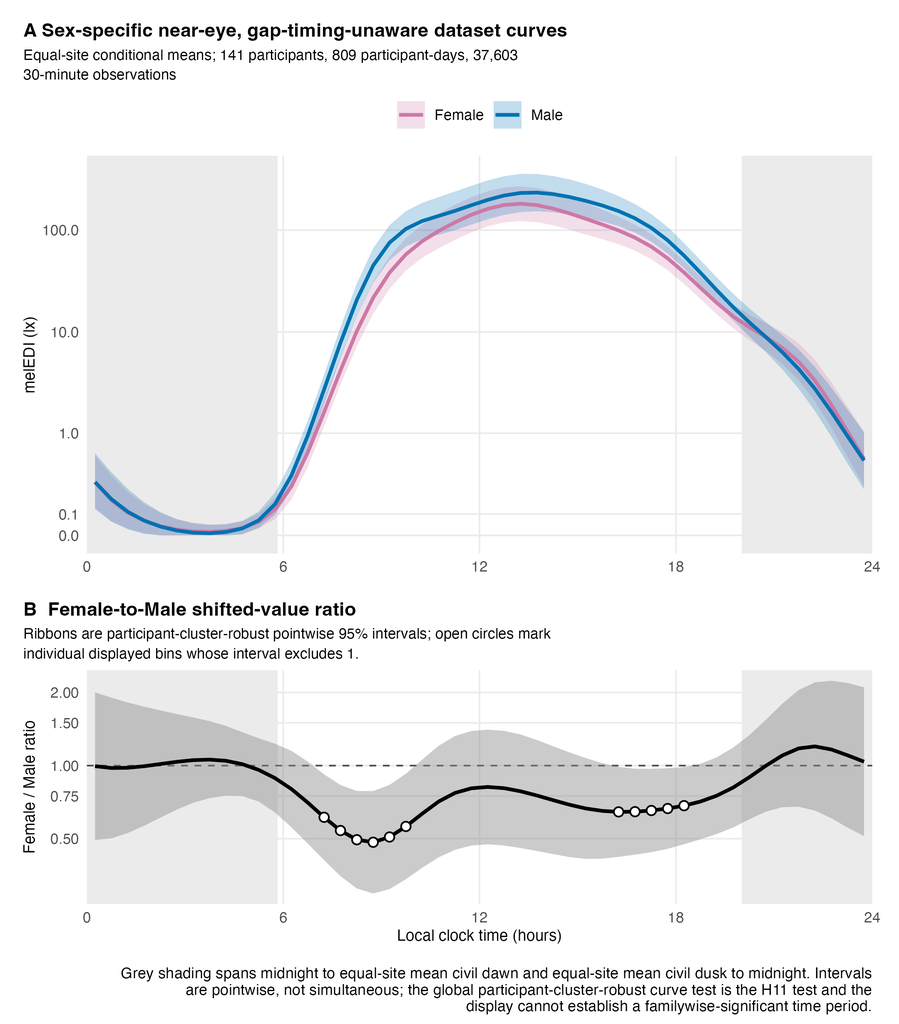

Near-eye gap-timing-unaware sensitivity. Participant-cluster-robust 95% intervals are pointwise, not simultaneous; the global curve test is the sensitivity test.

**Chest**

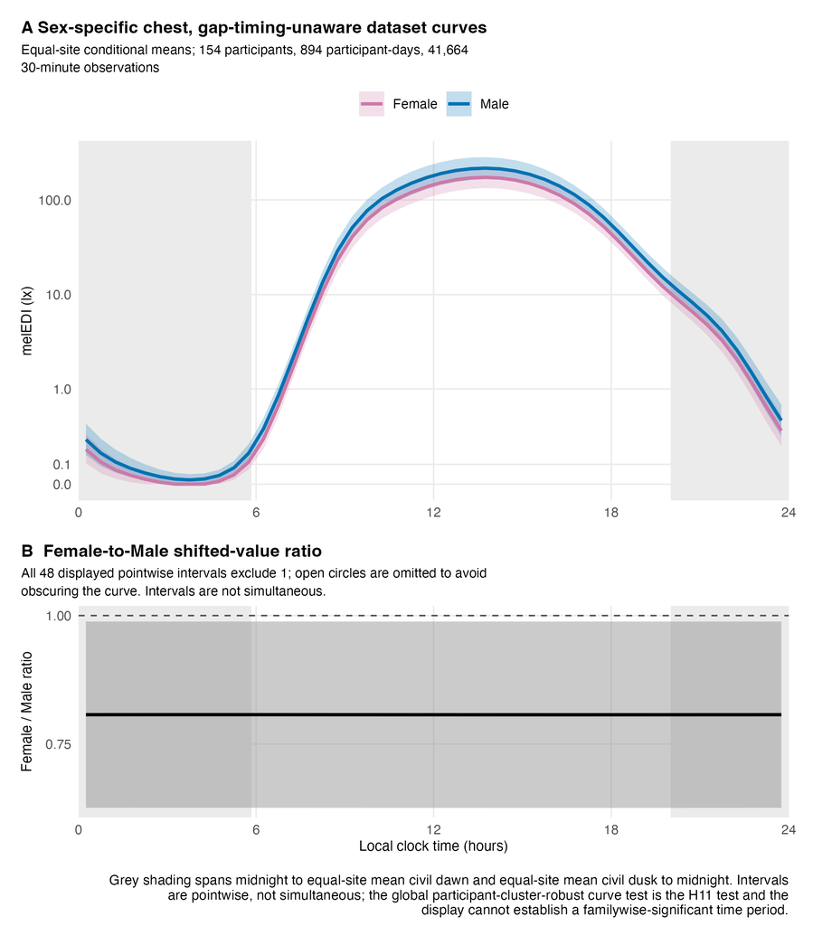

Chest gap-timing-unaware sensitivity. All 48 displayed pointwise intervals exclude one, so redundant open circles are omitted. The intervals are not simultaneous; the global curve test is the sensitivity test.

## 7 V0 reproduction and change attribution

### 7.1 Exact recovered V0 formulas

These evaluated formula objects reproduce the V0 Wilkinson specifications for audit comparison only. They were not refitted in the accepted analysis.

**Exact V0 temporal formulas**

```r
cat(h11_formula_text(formulas$v0_temporal_null), "\n")
```

```
lzMEDI ~ s(Time, k = 12) + s(Time, photoperiod.state, bs = "sz", k = 12) + s(Time, site, bs = "sz", k = 12) + s(Time, Id, bs = "fs") + s(Id_date, bs = "re")
```

**Exact V0 temporal formulas**

```r
cat(h11_formula_text(formulas$v0_temporal_full), "\n")
```

```
lzMEDI ~ s(Time, k = 12) + s(Time, photoperiod.state, bs = "sz", k = 12) + s(Time, sex, bs = "sz", k = 12) + s(Time, site, bs = "sz", k = 12) + s(Time, Id, bs = "fs") + s(Id_date, bs = "re")
```

**Exact V0 contextual formulas**

```r
cat(h11_formula_text(formulas$v0_activity_only), "\n")
```

```
lzMEDI ~ s(Time, k = 12) + s(Time, photoperiod.state, bs = "sz", k = 12) + s(Time, activity, bs = "sz", k = 12) + s(Time, site, bs = "sz", k = 12) + s(Time, Id, bs = "fs") + s(Id_date, bs = "re")
```

**Exact V0 contextual formulas**

```r
cat(h11_formula_text(formulas$v0_activity_plus_sex), "\n")
```

```
lzMEDI ~ s(Time, k = 12) + s(Time, photoperiod.state, bs = "sz", k = 12) + s(Time, sex, bs = "sz", k = 12) + s(Time, activity, bs = "sz", k = 12) + s(Time, site, bs = "sz", k = 12) + s(Time, Id, bs = "fs") + s(Id_date, bs = "re")
```

The frozen V0 figures are reproduced unchanged below. Their original curves and uncertainty are provenance evidence, not accepted inference. In particular, the near-eye red segment was a pointwise-to-period overclaim, and its caption incorrectly referred to work versus free days although the plotted contrast was biological sex. The corrected robust figures above retain the intended two-panel structure and do not repeat either claim.

**V0 near eye**

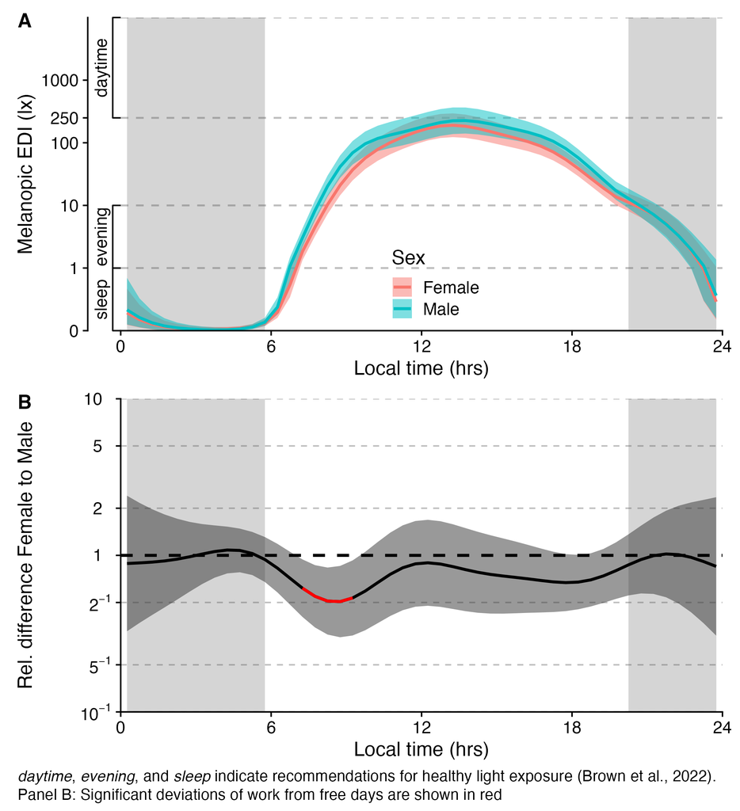

Frozen V0 near-eye H11 figure, reproduced without alteration for audit comparison. Its red interval and original caption are not treated as valid simultaneous daily-curve inference.

**V0 chest**

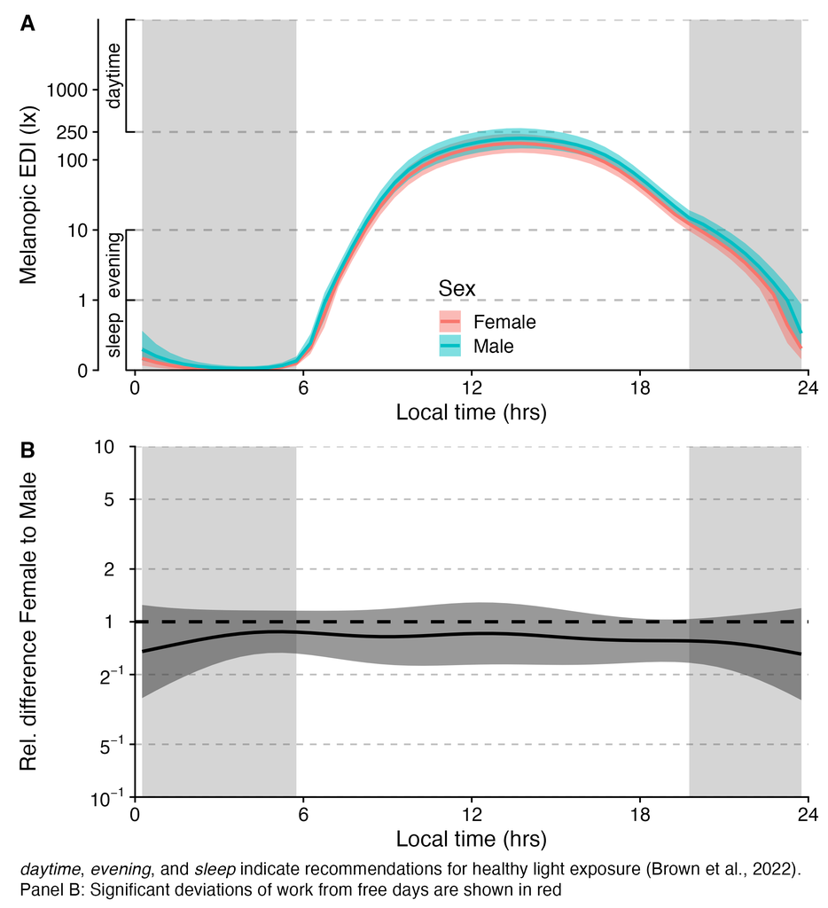

Frozen V0 chest H11 figure, reproduced without alteration for audit comparison.

The same-frame comparison separates model/inference changes from preparation changes. On the gap-timing-unaware frame, replacing V0’s separately estimated- rho fREML AIC comparison and omitted parametric sex level with the accepted joint robust test changes the chest conclusion from unsupported (V0 raw p = 0.414) to supported (raw p = **0.037** and BH-adjusted p = **0.037**). Near eye remains supported, but its accepted raw p = **0.026** and BH-adjusted p = **0.026** replace the decision-invalid V0 raw p = <0.001. Moving from the gap- timing-unaware frame to the primary frame then preserves both accepted conclusions; that second change is attributable to data preparation.

Near-eye V0, model/inference, and preparation comparison

The V0 raw p-value is not bolded because that row is not decision-valid.

| Layer | Participants | Participant-days | Observations | V0 ΔAIC | Robust F | Raw p | Status | Attribution |
| --- | --- | --- | --- | --- | --- | --- | --- | --- |
| V0 recovered result | 141 | 809 | 37,603 | 7.82 | NA | <0.001 | V0 reopened; not decision-valid | reference V0 result |
| New implementation on gap-timing-unaware data | 141 | 809 | 37,603 | NA | 20.50 | **0.026** | Supported | model/inference implementation relative to V0 on the corresponding gap-timing-unaware frame |
| New implementation on main repaired data | 141 | 816 | 37,756 | NA | 20.95 | **0.028** | Supported | data preparation after holding the new implementation fixed |

Chest V0, model/inference, and preparation comparison

The same gap-timing-unaware frame isolates the consequence of changing the model and inference.

| Layer | Participants | Participant-days | Observations | V0 ΔAIC | Robust F | Raw p | Status | Attribution |
| --- | --- | --- | --- | --- | --- | --- | --- | --- |
| V0 recovered result | 154 | 894 | 41,664 | −3.13 | NA | 0.414 | V0 reopened; not decision-valid | reference V0 result |
| New implementation on gap-timing-unaware data | 154 | 894 | 41,664 | NA | 4.42 | **0.037** | Supported | model/inference implementation relative to V0 on the corresponding gap-timing-unaware frame |
| New implementation on main repaired data | 154 | 902 | 41,842 | NA | 4.88 | **0.029** | Supported | data preparation after holding the new implementation fixed |

## 8 Model and robust-inference diagnostics

All four final models are **acceptable with specified limitations**. Each converged without a serious warning, the Female and Male cyclic curves close at midnight, the inherited site deviations satisfy their sum-to-zero constraint, and no severe basis-dimension flag was found. The accepted boundary-aware AR(1) step reduced final lag-1 residual correlation to 0.083 near eye and 0.070 at the chest on the primary dataset.

Residual tails remain heavier than Gaussian, absolute residual size is related to fitted level, and the rich site/participant/day smooth structure remains concurved. These are inherited H02 limitations. Participant-cluster robust inference protects the sex test against heteroskedasticity, non-Gaussian score variance, and residual dependence remaining within participants, but it does not make the conditional mean model causal or generalise beyond the fixed site support.

Explicit diagnostic assessment

Acceptability is assessed per final fitted run, not inferred from convergence alone.

| Analysis | Classification | Converged | Warnings absent | Cyclic closure | Site constraint | Final lag-1 correlation | Severe k flags |
| --- | --- | --- | --- | --- | --- | --- | --- |
| Near eye — primary dataset | acceptable with specified limitations | TRUE | TRUE | TRUE | TRUE | 0.083 | 0 |
| Chest — primary dataset | acceptable with specified limitations | TRUE | TRUE | TRUE | TRUE | 0.070 | 0 |
| Near eye — gap-timing-unaware dataset | acceptable with specified limitations | TRUE | TRUE | TRUE | TRUE | 0.082 | 0 |
| Chest — gap-timing-unaware dataset | acceptable with specified limitations | TRUE | TRUE | TRUE | TRUE | 0.071 | 0 |

Participant-cluster robust-inference diagnostics

Delete-one values recompute the sandwich with coefficients held fixed; they are not model refits.

| Placement | Participants | Reference rank | Denominator df | Largest participant meat share | Effective participants (trace) | Delete-one p range | Minimum covariance eigenvalue | Context runtime (seconds) |
| --- | --- | --- | --- | --- | --- | --- | --- | --- |
| Near eye | 141 | 9.7 | 131 | 2.7% | 87.0 | 0.023–0.029 | −6.65 × 10<sup>−17</sup> | 16.3 |
| Chest | 154 | 1.0 | 152 | 7.5% | 42.9 | 0.029–0.029 | −1.88 × 10<sup>−17</sup> | 20.4 |

**Near-eye residual dependence**

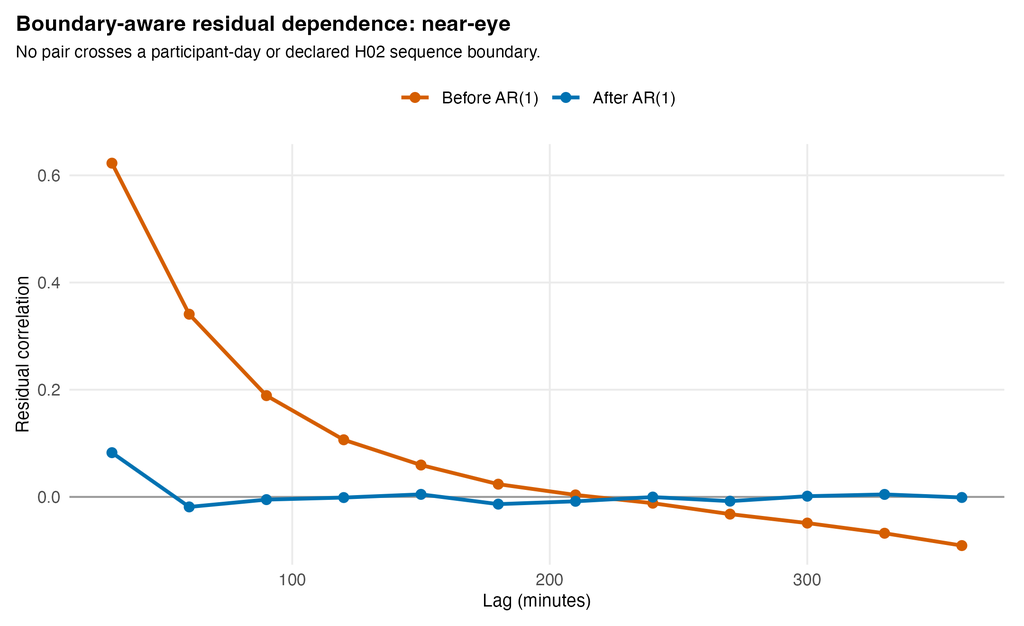

Boundary-aware near-eye residual correlation before and after applying the accepted AR(1) working structure. No pair crosses a participant-day or declared sequence boundary.

**Chest residual dependence**

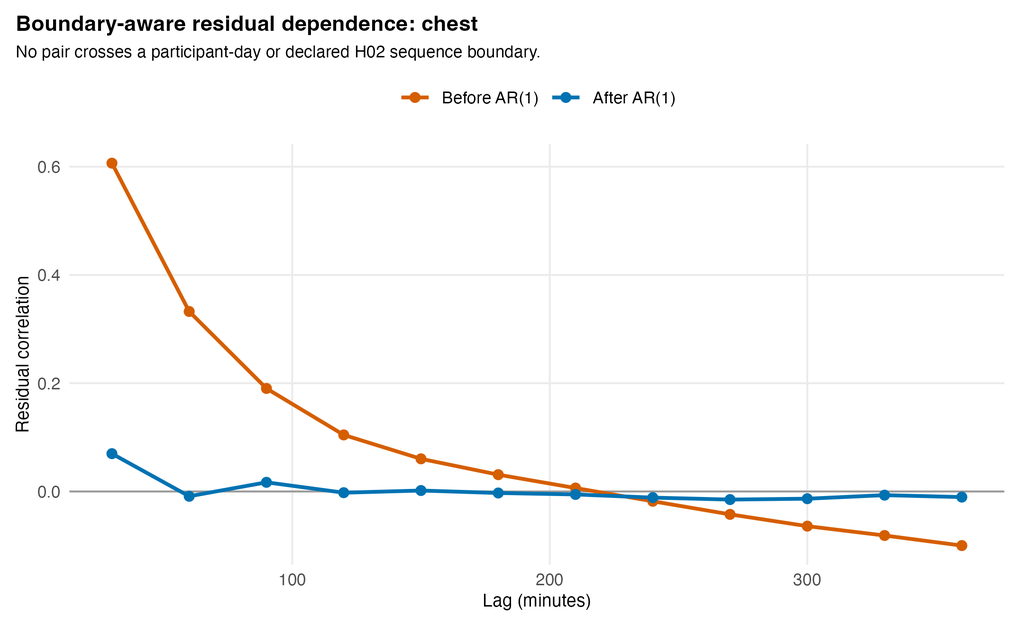

Boundary-aware chest residual correlation before and after applying the accepted AR(1) working structure. No pair crosses a participant-day or declared sequence boundary.

## 9 Paired placement display applicability (REPORT-009)

An H05-style near-eye-on-x/chest-on-y identity scatter is **not valid** for these Stage 2 temporal results. The accepted all-available fits use different samples (141 versus 154 participants; 37,756 versus 41,842 observations), and there is no predeclared scalar temporal estimand. Although stored H02 paired frames exist for 112 participants, 643 participant-days, 29,786 matched observations, and 8 sites, no H11 model has been fitted to those paired frames. Fitting one solely to create the plot is prohibited.

The closest valid display is therefore the separate primary near-eye and complementary chest curve panels above, with their exact samples stated and no claim of equivalence or placement agreement. **No paired source-data CSV is created** because no valid paired H11 fitted estimands exist at this stage.

REPORT-009 applicability assessment

Unmatched all-available placement results are not plotted against each other.

| Stored paired participants | Stored paired participant-days | Stored paired observations | H11 paired fitted outputs | Scalar identity plot applicable | Paired source-data CSV |
| --- | --- | --- | --- | --- | --- |
| 112 | 643 | 29,786 | FALSE | FALSE | Not created |

## 10 Deferred sensitivities and computation gates

The registered hourly geometric-mean outcome, paired common-sample fits, leave-one-site-out refits, all-zero-inclusive scenario, alternative H02 model forms, and activity context remain outside this execution. In particular, leave-one-site-out work remains important because sparse sex cells at UCR and TUM could influence a fixed-site curve, but it requires its later gate.

Deferred H11 analyses

No expensive side analysis was run before its gate.

| Scenario | Scope | Status | Why deferred | Could change interpretation |
| --- | --- | --- | --- | --- |
| registered_hourly_geometric_mean | near-eye and chest | deferred | Registered outcome sensitivity belongs to the full sensitivity battery after the Stage 2 gate. | Yes; it changes epoch, aggregation, support, and the dependence structure. |
| paired_common_sample | near-eye and chest | deferred | The placement-matched sensitivity requires four additional preliminary/final BAM fits and remains behind the Stage 2 result gate. | Yes; it can distinguish placement differences from all-available sample composition. |
| leave_one_site_out | near-eye primary, chest if warranted | deferred | Repeated refits are computationally expensive and explicitly permitted to remain outside Stage 2. | Yes; sparse sex cells at UCR and TUM could influence the primary curve. |
| all_zero_inclusive | near-eye and chest | blocked_shared_input | The coordinator has not supplied the approved H02-compatible all-zero-inclusive frame. | Yes; retaining otherwise eligible exact-all-zero participant-days can change time patterns. |
| H02_model_form | near-eye first | deferred_separate_gate | Alternative temporal bases and response families would reopen inherited H02 decisions. | Yes; high exact-zero mass, tails, and concurvity motivate a later robustness check. |
| activity_context | near-eye and chest | deferred_separate_gate | The H04 activity dictionary and exact activity-complete common sample are not yet approved for H11. | Yes; it may contextualize attenuation but cannot establish behaviour or mediation. |

## 11 Figure readability and final-size QA (REPORT-011)

All six generated Stage 2 figures and both frozen V0 audit figures were inspected at their final report display size. Important text is at least 7 pt for generated figures. The chest ratio panels suppress 48 redundant open circles when all bins exclude one pointwise. No clipping, overlap, distorted text, awkward wrapping, disproportionate data region, or indistinguishable central mark remains. Captions and alt text state interval scope and the historical limitations of the frozen V0 figures.

REPORT-011 final-size visual inspection

Detailed notes and the complete checklist are preserved in the H11 QA artifact.

| Figure | Minimum important text (pt) | No clipping | No overlap | Text readable | Marks distinguishable | Status |
| --- | --- | --- | --- | --- | --- | --- |
| h11_near_eye_pointwise | 7.0 | TRUE | TRUE | TRUE | TRUE | PASS |
| h11_chest_pointwise | 7.0 | TRUE | TRUE | TRUE | TRUE | PASS |
| h11_v0_prepared_near_eye_pointwise | 7.0 | TRUE | TRUE | TRUE | TRUE | PASS |
| h11_v0_prepared_chest_pointwise | 7.0 | TRUE | TRUE | TRUE | TRUE | PASS |
| h11_near_eye_pointwise_residual_acf | 7.0 | TRUE | TRUE | TRUE | TRUE | PASS |
| h11_chest_pointwise_residual_acf | 7.0 | TRUE | TRUE | TRUE | TRUE | PASS |
| v0_near_eye_frozen | 7.0 | TRUE | TRUE | TRUE | TRUE | PASS |
| v0_chest_frozen | 7.0 | TRUE | TRUE | TRUE | TRUE | PASS |

## 12 Interpretation

The accepted analysis supports an association between recorded biological sex and the complete conditional temporal melEDI curve in the primary near-eye data. Complementary chest evidence points in the same global direction. The near-eye curve difference varies descriptively over clock time, whereas the chest difference is estimated as almost constant, but the planned BH-adjusted decomposition does not isolate either level or shape as a supported component. Pointwise intervals contextualise the curves; they do not identify a familywise-significant clock-time period.

The effect-size pilot indicates that the biological-sex block adds negligible in-sample fitted relevance despite a supported global curve test. That combination is possible: a precisely estimated structured difference can be statistically supported yet account for very little of the outcome’s total within- and between-person variation. The association is not causal and cannot be generalised to a population of sites without the deferred site sensitivity.

## 13 Author approval gate

Please decide the following before any production computation or Stage 3 reader-facing notebook is created:

1. **H11-STAGE2-001 — scientific result:** approve the supported primary near-eye complete-curve result, supported complementary chest result, and the unsupported BH-adjusted level/shape decompositions.
2. **H11-STAGE2-002 — pointwise reporting:** approve the pointwise 95% curve displays and the explicit prohibition on significant-period claims.
3. **H11-STAGE2-003 — V0 comparison:** approve the attribution that the chest conclusion changes because of model/inference implementation on the same gap-timing-unaware frame, while the subsequent preparation change preserves both robust conclusions.
4. **H11-STAGE2-004 — diagnostics:** approve the assessment “acceptable with specified limitations.”
5. **H11-COMPUTE-001 — optional production pilot follow-up:** either approve a 2,000-resample fixed-prediction hierarchical effect-size run, based on the measured 50-resample pilot, or retain pilot estimates as audit-only and omit production intervals.
6. **H11-STAGE3-001 — next gate:** after resolving H11-COMPUTE-001, authorise Stage 3 sensitivity/report construction. Stage 3 will add the required “Answer in brief” callout from verified accepted outputs; it has not been added to this author-facing Stage 2 report.

Work stops here pending explicit author approval.